# R Notebook

# 1. Loading Data

### Data loaded into dataframe

```r
rm(list=ls())

coal_df = read.csv(file = 'dataset_Nicholas-Tony.csv')
```

# 2. Mean and Variance of each variable

### Thickness

```r
cat("Mean thickness: ", mean(coal_df$Thickness))
```

```
Mean thickness:  10.09062
```

```r
cat("\nVariance of thickness: ", var(coal_df$Thickness))
```

```
Variance of thickness:  2.154481
```

### Accumulation

```r
cat("Mean accumulation: ", mean(coal_df$Accumulation))
```

```
Mean accumulation:  8143.118
```

```r
cat("\nVariance of accumulation: ", var(coal_df$Accumulation))
```

```
Variance of accumulation:  26119092
```

Accumulation has a very large variance. In the Gaussian case, this would result in many negative values for accumulation. Since accumulation is a physical nonnegative quantity, it cannot be distributed in this way. The large variance is consistent with the given model, with a multimodal distribution (sum of Gaussians).

### Lignite Quality Index

```r
cat("Mean lignite quality: ", mean(coal_df$LQ))
```

```
Mean lignite quality:  0.29
```

```r
cat("\nVariance of lignite quality: ", var(coal_df$LQ))
```

```
Variance of lignite quality:  0.2079798
```

Only 29% of the observations have quality index 1. 71% have quality index 0. Variance matches Bernoulli RV with $p = 0.29$, $p(1-p) = 0.2059$.

# 3. Histograms of each variable

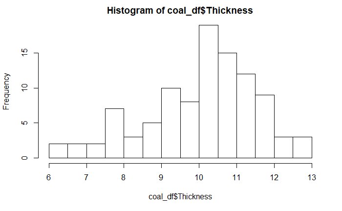

```r
hist(coal_df$Thickness, breaks = 10)
```

The curve is bell-shaped with a single mode around the average at 10. The curve shows a slight negative skew. Median is 10.38, slightly higher than mean.

Given model for Thickness is $\mu = 10$, $\sigma^2 = 4$.

Testing validity of given model with 1-sample Kolmogorov-Smirnov test:

```r
ks.test(coal_df$Thickness, pnorm, 10, 2)
```

```
    One-sample Kolmogorov-Smirnov test

data:  coal_df$Thickness
D = 0.13042, p-value = 0.06661
alternative hypothesis: two-sided
```

The p-value of 0.06661 exceeds the significance 0.05, so we do not reject the hypothesis that the sample was drawn from the distribution with these parameters $\mu = 10$, $\sigma^2 = 4$.

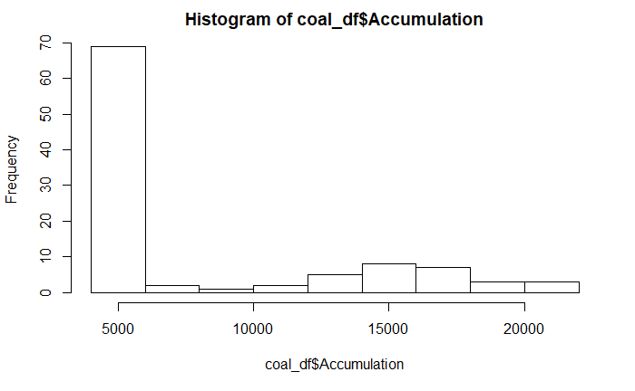

```r
hist(coal_df$Accumulation, breaks=10)
```

The accumulation is bimodal, one mode centered at low values with low variance, and the other with a high mean and high dispersion.

Plotting densities separately for lignite quality classes shows how lignite quality is strongly associated with accumulation.

(Lignite quality = 1 in blue, lignite quality = 0 in black)

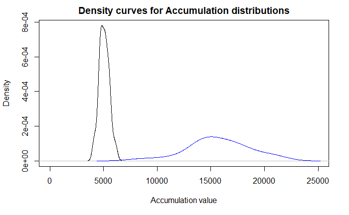

```r
plot(density(coal_df[coal_df$LQ == 0,]$Accumulation), xlim = c(0,25000), main="Density curves for Accumulation distributions",xlab="Accumulation value")
lines(density(coal_df[coal_df$LQ == 1,]$Accumulation), col='blue')
```

Lignite quality 1 has a distribution centered near 15000 with high variance. Lignite quality 0 has a distribution centered near 5000 with low variance.

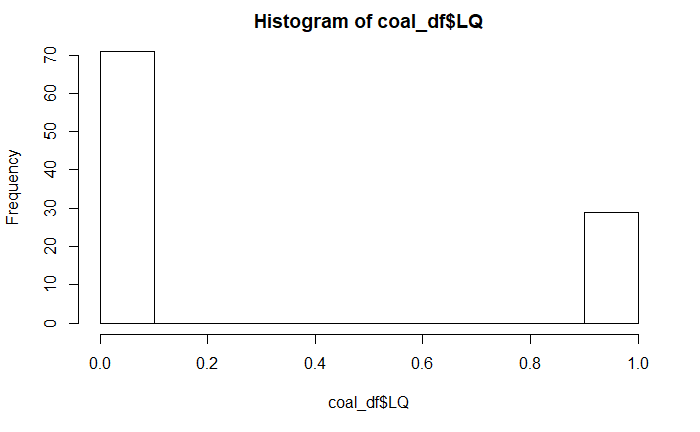

```r
hist(coal_df$LQ)
```

As predicted from the mean, only 29% of the observations have quality index 1. Roughly 71% have quality index 0.

# 4. Conditional simulation of thickness T on discretization grid

Preparing the RGeostats db object

```r
library(RGeostats)

#Changing the quality index to avoid issue with 0 value

if (any(coal_df$LQ == 0)){
  coal_df$LQ = coal_df$LQ + 1
}


coal_db <- db.create(coal_df)

coal_db = db.locate(coal_db,3:4,"x")
coal_db = db.locate(coal_db,5,"z")
```

Simulating the thickness, modeled as a Gaussian random function with parameters $\mu = 10$ and $\sigma^2 = 4$.

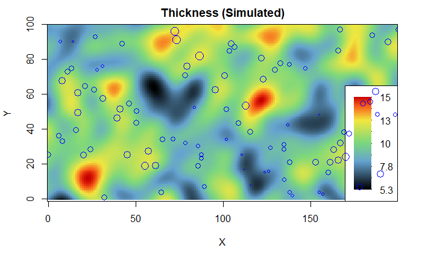

```r
sim_thickness <- function(indb, nsim = 1){

  indb = db.locate(indb, "Thickness", "z")

  Tmodel=model.create(vartype="Gaussian",range=20,sill=4,ndim=2)
  outdb = db.create(x0=c(0,0),dx=c(1,1),nx=c(200,100))
  neighb = neigh.create(ndim = 2, type = 0)
  simu <- simtub(nbtuba = 450, dbin=indb,dbout=outdb,model=Tmodel,neigh = neighb,mean = c(10),seed=933033161, nbsimu = nsim)
  return(simu)

}

simu = sim_thickness(coal_db)

plot(simu, xlab="X", ylab="Y", title="Thickness (Simulated)", pos.legend = 1)
plot(coal_db, add=T)
```

# 5. Conditional simulation of LQ (lignite quality index)

LQ is modelled as a thresholded GRF with constant proportion 0.5. The underlying GRF is standard Gaussian ($\mu = 0$ and $\sigma^{2} = 1$) and covariance is Gaussian with range 50.

```r
sim_lq <- function(indb, nsim = 1){

  indb = db.locate(indb, "LQ", "z")
  props = c(0.5,0.5)
  rule = rule.create(c("S", "F1", "F2"))
  voisin = neigh.create(type=0)
  outdb = db.create(x0=c(0,0),dx=c(1,1),nx=c(200,100))
  gaus = model.create("Gaussian", range=50)
  simlqin = simpgs(dbout=outdb, dbin=indb, rule=rule,props=c(0.5, 0.5), model1=gaus, neigh = voisin,seed=573738494, nbsimu = nsim)
  return(simlqin)

}

simlq0 = sim_lq(coal_db)
```

```
The model which only contains Gaussian components
has been stabilized by adding a small Nugget Effect
```

```r
plot(simlq0, xlab = "X", ylab="Y", title="Lithotype Quality Index (Simulated)")
plot(db.locate(coal_db, "LQ", "z"), add = T)
```

[output not shown]

The high range parameter favors large regions of the same value and limits variability at small scales.

# 6. Conditional simulation of the accumulation A

Where $LQ(x) = 0$, $\mu = 5000$ and $\sigma^{2} = 250000$

Where $LQ(x) = 1$, $\mu = 15000$ and $\sigma^{2} = 9\times10^6$.

Both $A_0$ and $A_1$ have Gaussian covariance with range 10.

$A_0$ and $A_1$ are simulated separately over the whole domain, conditioned *only* on the data with $LQ(x) = 0$ and $LQ(x) = 1$ respectively. Then the two simulations are joined together by creating a mask for the regions with $LQ(x) = 0$ and those with $LQ(x) = 1$ and assigning the appropriate simulated values in that region.

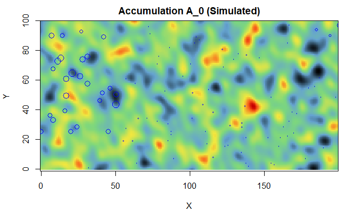

```r
sim_a0 <- function(indb, nsim=1){

  indb = db.locate(indb, "Accumulation", "z")

  #Selecting the data for condition
  coal_a0 = db.sel(indb, LQ==1)
  gaus_a0 = model.create("Gaussian", range=10, sill=250000)
  outdb = db.create(x0=c(0,0),dx=c(1,1),nx=c(200,100))
  neighb = neigh.create(ndim = 2, type = 0)
  sim =  simtub(dbin = coal_a0,dbout=outdb,model=gaus_a0,neigh = neighb,mean=5000,seed=939452503, nbsimu = nsim)
  return(sim)

}


sima0 = sim_a0(coal_db)

plot(sima0, pos.legend=0, xlab="X", ylab="Y", title="Accumulation A_0 (Simulated)")
plot(db.locate(coal_db, "Accumulation", "z"), add = T)
```

The smaller range parameter is immediately apparent when compared with the simulated thickness, which has a range parameter twice as large. Fluctuations between high and low values occur over much smaller distances.

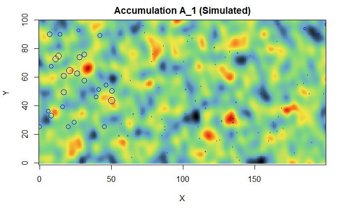

```r
sim_a1 <- function(indb, nsim=1){

  coal_a1 = db.locate(indb, "Accumulation", "z")
  coal_a1 = db.sel(coal_a1, LQ==2)
  gaus_a1 = model.create("Gaussian", range=10, sill=9000000)
  outdb = db.create(x0=c(0,0),dx=c(1,1),nx=c(200,100))
  neighb = neigh.create(ndim = 2, type = 0)
  sim_a1 =  simtub(dbin = coal_a1,dbout=outdb,model=gaus_a1,neigh = neighb,mean=15000,seed=707693329, nbsimu = nsim)
  return(sim_a1)

}

sima1 = sim_a1(coal_db)

plot(sima1, xlab="X", ylab="Y", title="Accumulation A_1 (Simulated)")
plot(db.locate(coal_db, "Accumulation", "z"),add=T)
```

```
NAs introduced by coercionNAs introduced by coercion
```

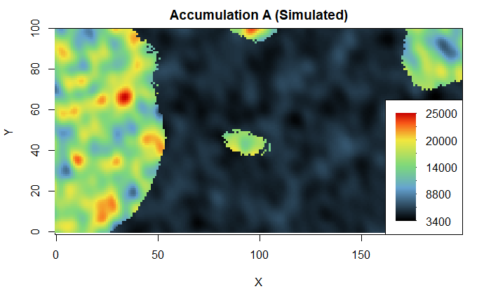

```r
join_sims_zonal <- function(sim0, sim1, zones){

  mask_1 = zones - 1
  mask_0 = 1 - mask_1
  pw_map = mask_0 * sim0 + mask_1 * sim1
  return(pw_map)

}

simulated_a0 = sima0@items$Simu.Accumulation.S1
simulated_a1 = sima1@items$Simu.Accumulation.S1

jsim = join_sims_zonal(simulated_a0,simulated_a1,simlq0@items$SimPGS.LQ.SFac1)

plot(db.locate(db.create(jsim,x0=c(0,0),dx=c(1,1),nx=c(200,100)),"jsim","z"), xlab = "X", ylab="Y", title="Accumulation A (Simulated)", pos.legend=1)
```

The map of simulated Accumulation shows the spatial distribution of the lignite qualities and accumulations, with the regions of high Accumulation corresponding to the areas with lignite quality 1, and the regions of low accumulation corresponding to the areas with lignite quality 0.

# 7. Calorific value

Compute and plot the calorific value $C(x) = \frac{A(x)}{T(x)}$.

```
NAs introduced by coercion
```

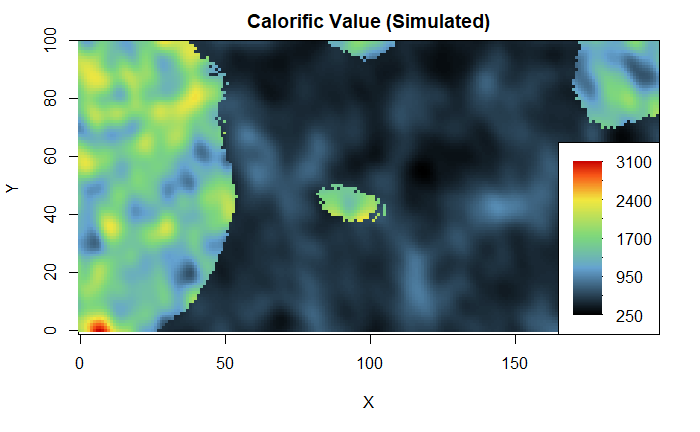

```r
cx = jsim/simu@items$Simu.Thickness.S1

cxdb = db.create(cx,x0=c(0,0),dx=c(1,1),nx=c(200,100))
cxdb = db.locate(cxdb, 4, "z")
plot(cxdb, xlab="X", ylab="Y", title="Calorific Value (Simulated)",pos.legend=1)
```

The calorific value is determined as $C(x) = \frac{A(x)}{T(x)}$. In a given region of the map with a single lignite quality value, the calorific value definition simplifies to $C(x) = \frac{A_{1}(x)}{T(x)}$ (if LQ=1) or $C(x) = \frac{A_{0}(x)}{T(x)}$ (if LQ = 0). In both cases, the calorific value is the ratio of two Gaussian distributions, so the values will be distributed according to a ratio distribution. The spatial distribution of calorific values has intermediate range between thickness and accumulations; while there are short-range fluctuations they are not as extreme as in the accumulation variable. The area of high values located in the lower left hand corner corresponds to a minima of the thickness simulation.

# 8. Value of $C_{v}$ on each panel

Value of $C_{v}$ on each panel averaging over the 100 contained values.

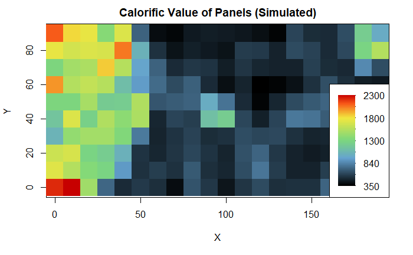

```r
cgrid = db.create(x0=c(0,0),dx=c(10,10),nx=c(20,10))

panel_q =blockstat(cgrid, cxdb, fun='mean')

plot(panel_q, xlab = "X", ylab = "Y", title = "Calorific Value of Panels (Simulated)",pos.legend=1)
```

# 9. Quality tonnage and mean quality above cutoff curves

Quality tonnage and mean quality above cutoff for cut-off varying from 1000 to 2500.

Tonnage given by $t(c)=t \sum_{i=1}^{N} 1_{v}\left(C_{v}\left(x_{i}\right)>c\right)$. Tonnage is normalized, so the returned value must be multiplied by $200 \times 10^{6}$ to find the correct value.

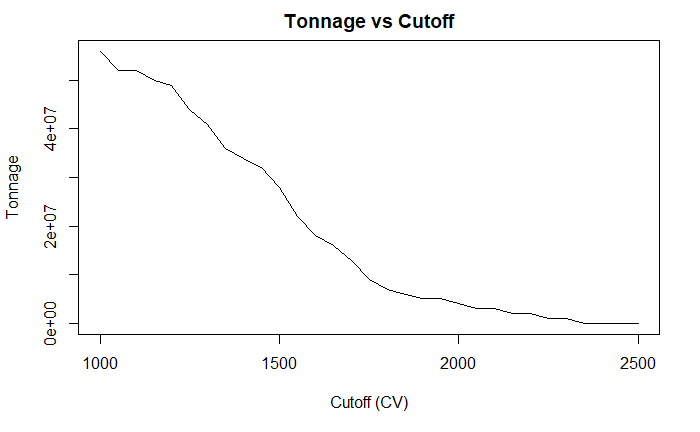

```r
sel = selectivity(panel_q, cuts = seq(1000,2500,50), flag.plot = F)

plot(sel[,1], 200*(10**6)*sel[,2], type='l', main="Tonnage vs Cutoff", xlab = "Cutoff (CV)", ylab="Tonnage")
```

Interpreted in terms of the distribution, we can clearly see the change in slope as the low-valued, low-variance distribution gives way to the high-valued, high-dispersion distribution. This corresponds to the shallow slope above CV 1750 or so as the blocks transition from $A_0$ to $A_1$.

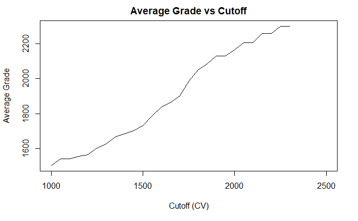

```r
plot(sel[,1],sel[,5],type = 'l',main="Average Grade vs Cutoff", xlab = "Cutoff (CV)", ylab="Average Grade")
```

Average grade given by $m(c)=\frac{\sum_{i=1}^{N} C_{v}\left(x_{i}\right) \mathbb{1}_{v}\left(C_{v}\left(x_{i}\right)>c\right)}{\sum_{i=1}^{N} \mathbb{1}_{v}\left(C_{v}\left(x_{i}\right)>c\right)}$.

Here, we can also see a transition from a smooth area to a stepwise curve at high cutoff values. The very few remaining blocks cause abrupt changes in the average grade in the as they are excluded at successively higher cutoffs.

# 10. Simulations of Calorific Value

100 simulations

```r
sthicks = sim_thickness(coal_db, nsim = 100)
slqs = sim_lq(coal_db, nsim = 100)
```

```
The model which only contains Gaussian components
has been stabilized by adding a small Nugget Effect
```

```r
sima0 = sim_a0(coal_db, nsim = 100)
sima1 = sim_a1(coal_db, nsim = 100)
```

Calculating statistics on individual simulations

```r
for (idx in 4:103){

  thickn = sthicks@items[[idx]]
  simlq = slqs@items[[idx]]
  simulated_a0 = sima0@items[[idx]]
  simulated_a1 = sima1@items[[idx]]
  ajsim = join_sims_zonal(simulated_a0,simulated_a1,simlq)

  cx = ajsim/thickn

  cxdb = db.create(cx,x0=c(0,0),dx=c(1,1),nx=c(200,100))
  cxdb = db.locate(cxdb, 4, "z")

  cgrid = db.create(x0=c(0,0),dx=c(10,10),nx=c(20,10))
  panel_q = blockstat(cgrid, cxdb, fun='mean')

  sel = selectivity(panel_q, cuts = seq(1000,2500,50),flag.plot = F)

  if (idx == 4){

    z = sel[,1]

    sels = vector("list", 103)
    sels[[idx]] = sel

  } else {
    sels[[idx]] = sel

  }
}



Mmatrix = sels[[4]][,5]
Tmatrix = sels[[4]][,2]

for (idx in 5:103){
  Mmatrix = cbind(Mmatrix, sels[[idx]][,5])
  Tmatrix = cbind(Tmatrix, sels[[idx]][,2])
}
```

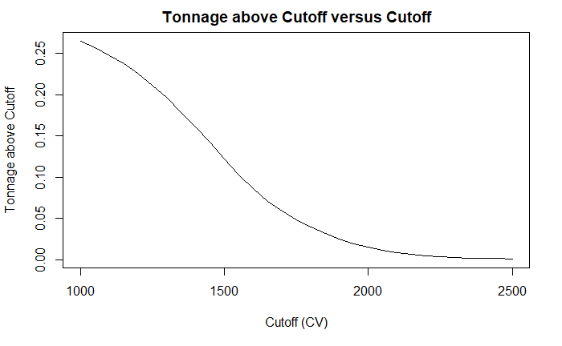

```r
Tm = rowMeans(Tmatrix, na.rm = T, dims = 1)
plot(z, Tm, type = 'l',main="Tonnage above Cutoff versus Cutoff", xlab="Cutoff (CV)", ylab ="Tonnage above Cutoff")
```

The curve is much smoother, transition around 1750 is still visible.

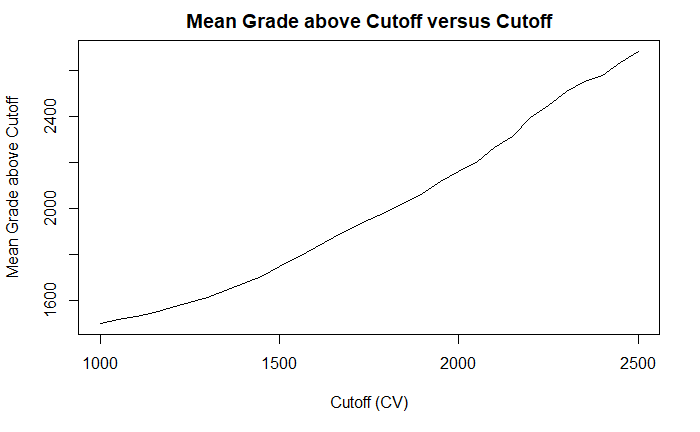

```r
mmu = rowMeans(Mmatrix, na.rm = T, dims = 1)
plot(z, mmu, type = 'l', main="Mean Grade above Cutoff versus Cutoff", xlab="Cutoff (CV)", ylab ="Mean Grade above Cutoff")
```

The average behavior of the Mean Grade curve is much smoother but the irregular behavior at high cutoff indicates that the effect of rare high grade blocks is still present in the average curves.

# 11. Empirical 95% Confidence Interval curves

```r
mmu = rowMeans(Mmatrix, na.rm = T, dims = 1)
plot(z, mmu, type = 'l', main="Mean Grade above Cutoff versus Cutoff", xlab="Cutoff (CV)", ylab ="Mean Grade above Cutoff")

mvar = apply(Mmatrix, 1, var, na.rm = T)
msd = sqrt(mvar)

lines(z, mmu + 1.96*msd, col="red")
```

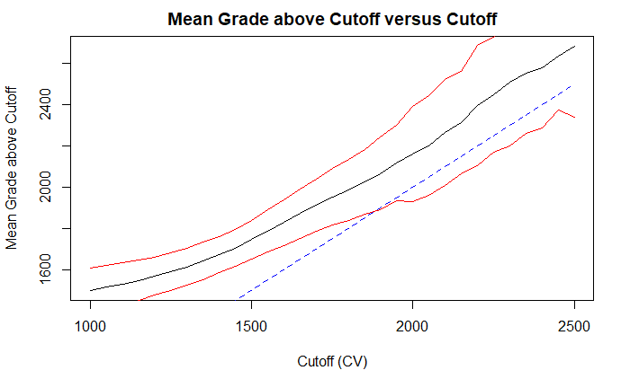

```r
lines(z, mmu - 1.96*msd, col="red")
lines(z, z, col="blue", lty="55")
```

The standard 95% CI is steady until cutoff $z$ near 1750 to 2000, when the distribution of curves begins to widen. Blocks over 2000 are rare, as averaging and ratios destroy the higher grades, so many simulations will not frequently contain blocks in this range. These high calorific value blocks are most likely to occur in simulations where the high accumulation and low thickness coincide spatially. This effect causes an increase in the standard deviation as the sample size decreases. Line y = x is also plotted (dotted line, in blue) as only values above this line are possible for this curve (mean grade above cutoff cannot be below cutoff.)

```r
Tm = rowMeans(Tmatrix, na.rm = T, dims = 1)
plot(z, Tm, type = 'l',main="Tonnage above Cutoff versus Cutoff", xlab="Cutoff (CV)", ylab ="Tonnage above Cutoff")

Tvar = apply(Tmatrix, 1, var, na.rm = T)
Tsd = sqrt(Tvar)

lines(z, Tm + 1.96*Tsd, col="red")
```

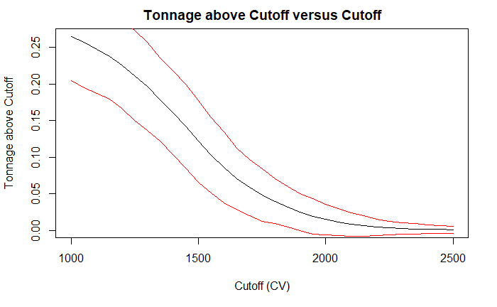

```r
lines(z, Tm - 1.96*Tsd, col="red")
```

The tonnage cutoff (quality tonnage) curve decreases with increasing cutoff as blocks are excluded. The curve shape changes between cutoff 1500 and cutoff 2000 where it passes from the cutoff values dominated by distribution $A_0$ to the region dominated by distribution $A_1$. As seen in the mean quality above cutoff curve, not many simulations producing blocks in this range. Many simulations will simply have zero at this level of cutoff, driving down the variance substantially. The combined effect of many simulations with zero tons above the high cutoff and drawing from a smaller set of blocks outweighs the larger variance of the higher grade blocks.